# onco

#### 0.背景知识一点点

oncoPredict是根据基因表达量来预测药物敏感性的R包。也就是说它可以根据你的样本基因表达量来告诉你每个药物的IC50值，这个值越低就说明药物越管用。

提到药物预测，还有一个pRRophetic包，建议不用看了，因为oncoPredict是它的plus版本。

还有一个cellMiner包，之前写过，可以翻翻看。

#### 1.载入数据

代码参考自：https://mp.weixin.qq.com/s/QRaTd-fIsqq6sPsLmOPvIw，一些背景知识也可以补充下.

在Training Data文件夹下存放着R包作者准备好的数据，用作药物预测的训练集。下载自：https://osf.io/c6tfx/

```r
rm(list = ls())
library(oncoPredict)
library(data.table)
library(gtools)
library(reshape2)
library(ggpubr)
dir='./DataFiles/DataFiles/Training Data/'
dir(dir)
```

```
## [1] "CTRP2_Expr (RPKM, not log transformed).rds"
## [2] "CTRP2_Expr (TPM, not log transformed).rds"
## [3] "CTRP2_Res.rds"
## [4] "GDSC1_Expr (RMA Normalized and Log Transformed).rds"
## [5] "GDSC1_Res.rds"
## [6] "GDSC2_Expr (RMA Normalized and Log Transformed).rds"
## [7] "GDSC2_Res.rds"
```

可以看到其中包括了Cancer Therapeutics Response Portal (CTRP)和Genomics of Drug Sensitivity in Cancer (GDSC)

两个数据库的数据，都是提供了基因表达矩阵和药物IC50表格。

```r
exp = readRDS(file=file.path(dir,'GDSC2_Expr (RMA Normalized and Log Transformed).rds'))
exp[1:4,1:4]
```

```
##        COSMIC_906826 COSMIC_687983 COSMIC_910927 COSMIC_1240138
## TSPAN6      7.632023      7.548671      8.712338       7.797142
## TNMD        2.964585      2.777716      2.643508       2.817923
## DPM1       10.379553     11.807341      9.880733       9.883471
## SCYL3       3.614794      4.066887      3.956230       4.063701
```

```r
dim(exp)
```

```
## [1] 17419   805
```

```r
drug = readRDS(file = file.path(dir,"GDSC2_Res.rds"))
drug <- exp(drug) #下载到的数据是被log转换过的，用这句代码逆转回去
drug[1:4,1:4]
```

```
##                Camptothecin_1003 Vinblastine_1004
## COSMIC_906826          0.3158373      0.208843106
## COSMIC_687983          0.2827342      0.013664227
## COSMIC_910927          0.0295671      0.006684071
## COSMIC_1240138         7.2165789               NA
##                Cisplatin_1005 Cytarabine_1006
## COSMIC_906826      1116.05899      18.5038719
## COSMIC_687983        26.75839      16.2943594
## COSMIC_910927        12.09379       0.3387418
## COSMIC_1240138             NA              NA
```

```r
dim(drug)
```

```
## [1] 805 198
```

```r
identical(rownames(drug),colnames(exp))
```

```
## [1] TRUE
```

drug是药物IC50值，exp是对应细胞系基因的表达矩阵。可以看到二者的样本名称是对应的。

#### 2.操练一下

```r
load("../4_tcga_model/TCGA-STAD_sur_model.Rdata")
test = exprSet
```

运行时间很长，所以if(F)注释掉。

```r
if(F){
  calcPhenotype(trainingExprData = exp,
                trainingPtype = drug,
                testExprData = test,
                batchCorrect = 'standardize',  #   "eb" for array,standardize  for rnaseq
                powerTransformPhenotype = TRUE,
                removeLowVaryingGenes = 0.2,
                minNumSamples = 10,
                printOutput = TRUE,
                removeLowVaringGenesFrom = 'rawData' )
}
```

R包Vignette里关于batchCorrect参数的说明

> batchCorrect options: “eb” for ComBat, “qn” for quantiles normalization, “standardize”, or “none”

> “eb” is good to use when you use microarray training data to build models on microarray testing data.

> “standardize is good to use when you use microarray training data to build models on RNA-seq testing data (this is what Paul used in the 2017 IDWAS paper that used GDSC microarray to impute in TCGA RNA-Seq data, see methods section of that paper for rationale)

R包Vignette里关于removeLowVaringGenesFrom参数的说明

> #Determine method to remove low varying genes. #Options are ‘homogenizeData’ and ‘rawData’ #homogenizeData is likely better if there is ComBat batch correction, raw data was used in the 2017 IDWAS paper that used GDSC microarray to impute in TCGA RNA-Seq data.

removeLowVaringGenesFrom,作者说的也模糊啊。随便吧。

#### 3.看看结果

这是运行之后的结果，被存在固定文件夹calcPhenotype_Output下。文件名也是固定的DrugPredictions.csv。因此一个工作目录只能计算一个数据，你可别混着用哦。

```r
testPtype <- read.csv('./calcPhenotype_Output/DrugPredictions.csv', row.names = 1,check.names = F)
testPtype[1:4, 1:4]
```

```
##                  Camptothecin_1003 Vinblastine_1004
## TCGA-CG-5722-01A        0.02011250      0.008784574
## TCGA-CG-5720-01A        0.02834292      0.012123971
## TCGA-CG-5719-01A        0.18266808      0.116742765
## TCGA-BR-8487-01A        0.04462644      0.015322733
##                  Cisplatin_1005 Cytarabine_1006
## TCGA-CG-5722-01A       5.220266        2.277029
## TCGA-CG-5720-01A      11.202529        1.979332
## TCGA-CG-5719-01A      64.177460       14.459116
## TCGA-BR-8487-01A      10.413535        1.950709
```

```r
dim(testPtype)
```

```
## [1] 337 198
```

```r
identical(colnames(testPtype),colnames(drug))
```

```
## [1] TRUE
```

198种药物IC50的预测结果就在这个表格里啦。

#### 结合高低风险画图

```r
load("../4_tcga_model/TCGA-STADcox_fp.Rdata")
Group = dat$Risk
Group = factor(Group,levels = c("low_risk","high_risk"))
identical(rownames(testPtype),rownames(dat))
```

```
## [1] TRUE
```

```r
a = apply(testPtype, 2, function(x){
  #x = testPtype[,1]
   wilcox.test(x~Group)$p.value
})
head(a)
```

```
##      Camptothecin_1003       Vinblastine_1004
## 0.01668445010637496090 0.00012329995911673872
##         Cisplatin_1005        Cytarabine_1006
## 0.02827684434385411422 0.00000016100827597428
##         Docetaxel_1007         Gefitinib_1010
## 0.00004131145391555938 0.00000000000009718701
```

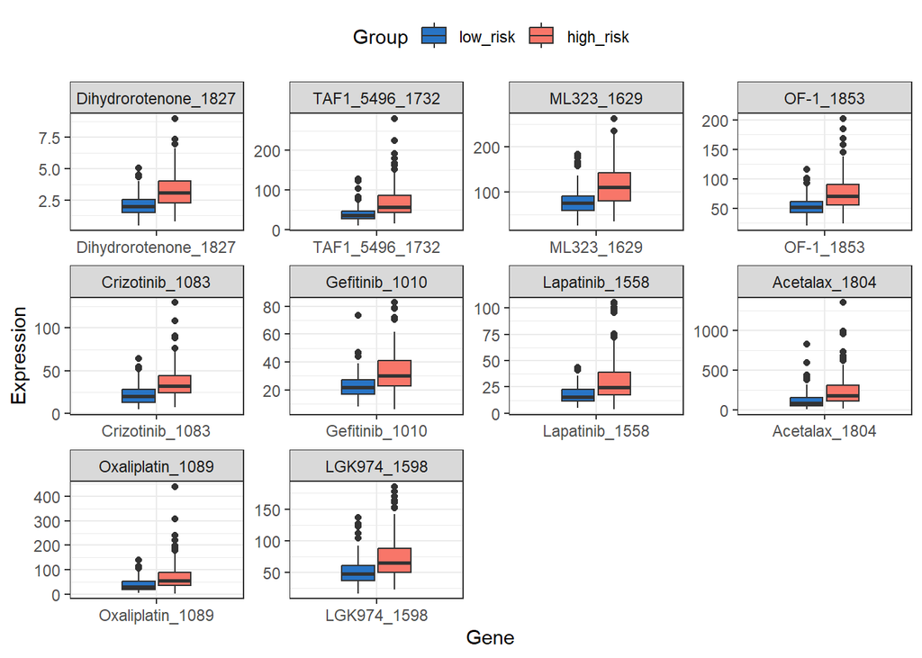

```r
#p值最小的10个药物
dg = names(head(sort(a),10))
library(tinyarray)
library(ggplot2)
draw_boxplot(t(testPtype[,dg]),Group)+
  facet_wrap(~ rows,scales = "free")
```